# Restaurant health inspections in NYC

April 24, 2016

## Introduction

- NYC Health Department restaurant **inspections, scores and grades** (e.g. A/B/C)
- How do a restaurant's **location** and type of **cuisine** affect its inspection results? E.g.:
  - Do restaurants in Manhattan have better scores than Queens or the Bronx?
  - Do restaurants in Chinatown and Flushing perform worse than Upper East Side?
  - Do Chinese restaurants have poorer hygiene than French or American restaurants?
- Data used (after cleanup and filtering): 2010 - 2016; 150k inspections (rows); 25k restaurants

## Grades by borough

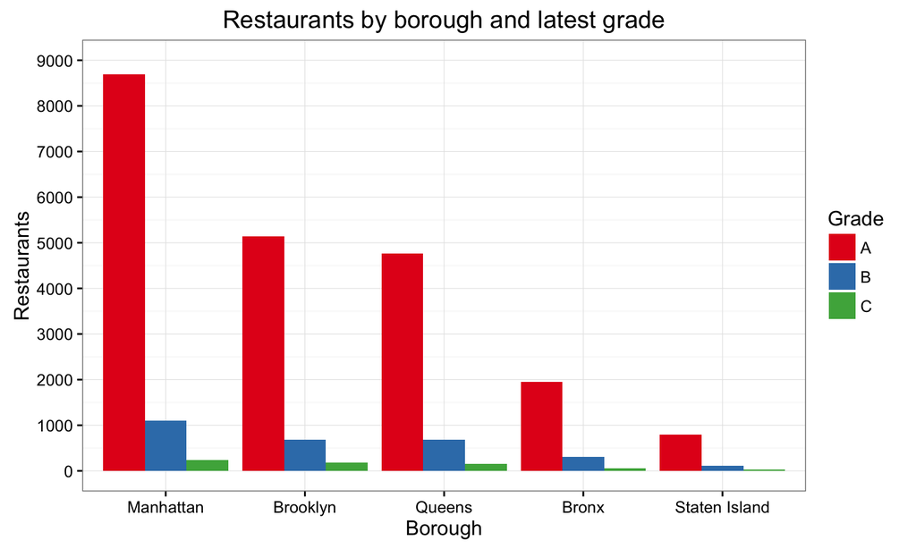

## Going deeper… Scores by borough

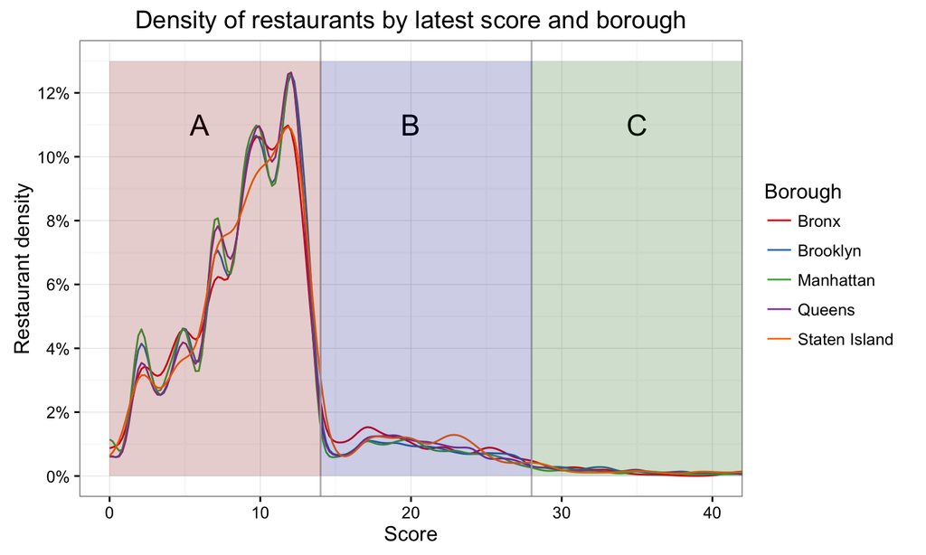

## Going deeper still… Scores by zipcode

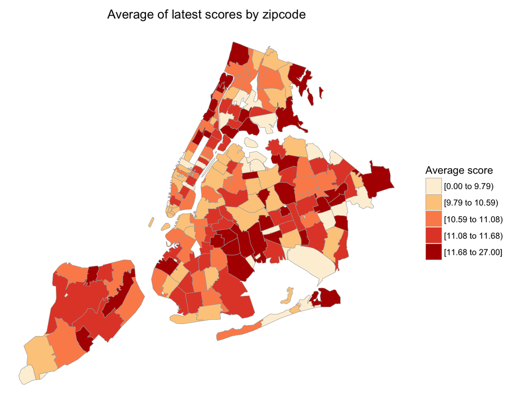

## What about inspection closures?

- Scores don't tie directly to restaurant closures (e.g. public health hazard)
- Defined the following ratios:
  - **Inspection closure ratio**: % of inspections that lead to the restaurant being closed
  - **Repeat closure ratio**: % of restaurants that were closed during more than one inspection cycle

## Closures by borough

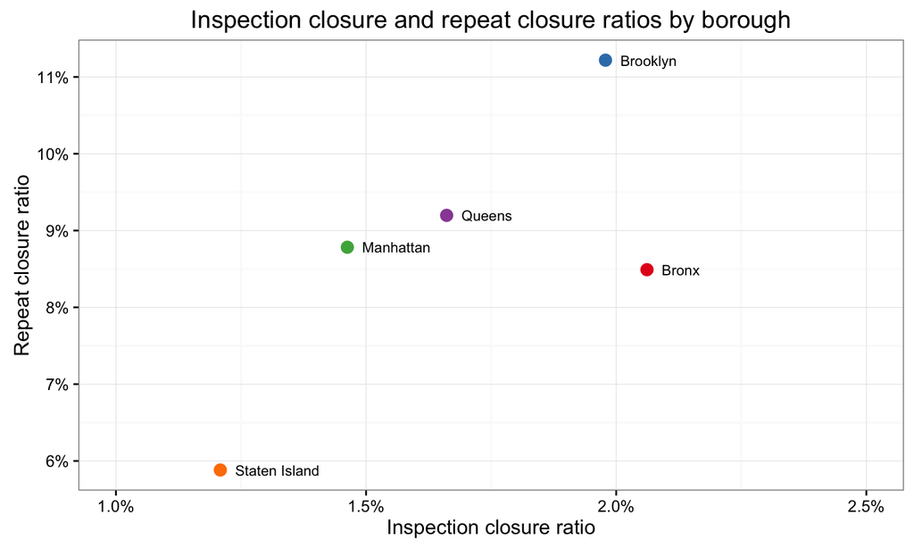